# Project I: World Population Trend and CO2 Emission

Shalom Dauphin NYARWAYA (20252MBI046)

11/4/2026

# 4.1 Load the data

```r
pop <- as.data.frame(readr::read_csv(file.path(data_dir, "world_population.csv"),
                                     show_col_types = FALSE))

# The "²" in two column names can break on some systems, so i gave them plain ASCII names
names(pop)[grepl("^Area", names(pop))]    <- "Area_km2"
names(pop)[grepl("^Density", names(pop))] <- "Density_km2"

co2 <- read.csv(file.path(data_dir, "CO2_emission.csv"),
                stringsAsFactors = FALSE)   # year columns become X1990 ... X2019
```

Two things to notice about the CO2 file:

- It contains the **2019 column twice** (`X2019` and `X2019.1`, identical values), so we drop the copy.
- The unit is **metric tons per capita**, not total tonnes.

```r
#here we are checking if the two columns are identical,if they are we print true and we delete one by setting it to null
all.equal(co2$X2019, co2$X2019.1)
```

```
## [1] TRUE
```

```r
co2$X2019.1 <- NULL
```

# 4.2 Exploratory data analysis (World Population Dataset)

```r
names(pop)                 # variable names
```

```
##  [1] "Rank"                        "CCA3"
##  [3] "Country/Territory"           "Capital"
##  [5] "Continent"                   "2022 Population"
##  [7] "2020 Population"             "2015 Population"
##  [9] "2010 Population"             "2000 Population"
## [11] "1990 Population"             "1980 Population"
## [13] "1970 Population"             "Area_km2"
## [15] "Density_km2"                 "Growth Rate"
## [17] "World Population Percentage"
```

```r
head(pop, 5)               # top 5 rows
```

```
##   Rank CCA3 Country/Territory          Capital Continent 2022 Population
## 1   36  AFG       Afghanistan            Kabul      Asia        41128771
## 2  138  ALB           Albania           Tirana    Europe         2842321
## 3   34  DZA           Algeria          Algiers    Africa        44903225
## 4  213  ASM    American Samoa        Pago Pago   Oceania           44273
## 5  203  AND           Andorra Andorra la Vella    Europe           79824
##   2020 Population 2015 Population 2010 Population 2000 Population
## 1        38972230        33753499        28189672        19542982
## 2         2866849         2882481         2913399         3182021
## 3        43451666        39543154        35856344        30774621
## 4           46189           51368           54849           58230
## 5           77700           71746           71519           66097
##   1990 Population 1980 Population 1970 Population Area_km2 Density_km2
## 1        10694796        12486631        10752971   652230     63.0587
## 2         3295066         2941651         2324731    28748     98.8702
## 3        25518074        18739378        13795915  2381741     18.8531
## 4           47818           32886           27075      199    222.4774
## 5           53569           35611           19860      468    170.5641
##   Growth Rate World Population Percentage
## 1      1.0257                        0.52
## 2      0.9957                        0.04
## 3      1.0164                        0.56
## 4      0.9831                        0.00
## 5      1.0100                        0.00
```

```r
tail(pop, 10)              # bottom 10 rows
```

```
##     Rank CCA3 Country/Territory      Capital     Continent 2022 Population
## 225   43  UZB        Uzbekistan     Tashkent          Asia        34627652
## 226  181  VUT           Vanuatu    Port-Vila       Oceania          326740
## 227  234  VAT      Vatican City Vatican City        Europe             510
## 228   51  VEN         Venezuela      Caracas South America        28301696
## 229   16  VNM           Vietnam        Hanoi          Asia        98186856
## 230  226  WLF Wallis and Futuna     Mata-Utu       Oceania           11572
## 231  172  ESH    Western Sahara     El Aaiún        Africa          575986
## 232   46  YEM             Yemen        Sanaa          Asia        33696614
## 233   63  ZMB            Zambia       Lusaka        Africa        20017675
## 234   74  ZWE          Zimbabwe       Harare        Africa        16320537
##     2020 Population 2015 Population 2010 Population 2000 Population
## 225        33526656        30949417        28614227        24925554
## 226          311685          276438          245453          192074
## 227             520             564             596             651
```

[output cut: 29 more lines]

```r
str(pop)                   # data types
```

```
## 'data.frame':    234 obs. of  17 variables:
##  $ Rank                       : num  36 138 34 213 203 42 224 201 33 140 ...
##  $ CCA3                       : chr  "AFG" "ALB" "DZA" "ASM" ...
##  $ Country/Territory          : chr  "Afghanistan" "Albania" "Algeria" "American Samoa" ...
##  $ Capital                    : chr  "Kabul" "Tirana" "Algiers" "Pago Pago" ...
##  $ Continent                  : chr  "Asia" "Europe" "Africa" "Oceania" ...
##  $ 2022 Population            : num  41128771 2842321 44903225 44273 79824 ...
##  $ 2020 Population            : num  38972230 2866849 43451666 46189 77700 ...
##  $ 2015 Population            : num  33753499 2882481 39543154 51368 71746 ...
##  $ 2010 Population            : num  28189672 2913399 35856344 54849 71519 ...
##  $ 2000 Population            : num  19542982 3182021 30774621 58230 66097 ...
##  $ 1990 Population            : num  10694796 3295066 25518074 47818 53569 ...
##  $ 1980 Population            : num  12486631 2941651 18739378 32886 35611 ...
##  $ 1970 Population            : num  10752971 2324731 13795915 27075 19860 ...
##  $ Area_km2                   : num  652230 28748 2381741 199 468 ...
##  $ Density_km2                : num  63.1 98.9 18.9 222.5 170.6 ...
##  $ Growth Rate                : num  1.026 0.996 1.016 0.983 1.01 ...
##  $ World Population Percentage: num  0.52 0.04 0.56 0 0 0.45 0 0 0.57 0.03 ...
```

```r
dim(pop)                   # shape (rows, columns)
```

```
## [1] 234  17
```

## Duplicates and missing values

```r
cat("Duplicate rows:", sum(duplicated(pop)), "\n")
```

```
## Duplicate rows: 0
```

```r
pop <- pop[!duplicated(pop), ]          # drop duplicates

colSums(is.na(pop))                     # missing values per column
```

```
##                        Rank                        CCA3
##                           0                           0
##           Country/Territory                     Capital
##                           0                           0
##                   Continent             2022 Population
##                           0                           0
##             2020 Population             2015 Population
##                           0                           0
##             2010 Population             2000 Population
##                           0                           0
##             1990 Population             1980 Population
##                           0                           0
##             1970 Population                    Area_km2
##                           0                           0
##                 Density_km2                 Growth Rate
##                           0                           0
## World Population Percentage
##                           0
```

## Outliers (box plots)

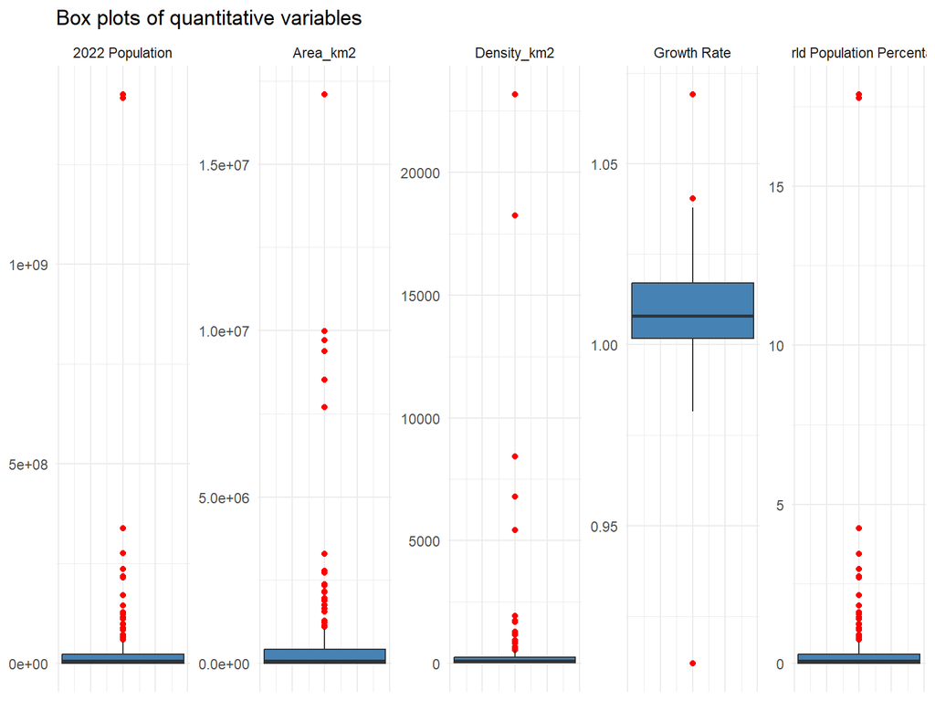

```r
quant_vars <- c("2022 Population", "Area_km2", "Density_km2",
                "Growth Rate", "World Population Percentage")

long <- pop |>
  select(all_of(quant_vars)) |>
  pivot_longer(everything(), names_to = "variable", values_to = "value")

ggplot(long, aes(y = value)) +
  geom_boxplot(fill = "steelblue", outlier.colour = "red") +
  facet_wrap(~ variable, scales = "free_y", nrow = 1) +
  labs(title = "Box plots of quantitative variables", y = NULL) +
  theme_minimal() + theme(axis.text.x = element_blank())
```

```r
# How many outliers by the 1.5 x IQR rule?
iqr_outliers <- sapply(quant_vars, function(v) {
  x <- pop[[v]]; q <- quantile(x, c(.25, .75)); i <- diff(q)
  sum(x < q[1] - 1.5 * i | x > q[2] + 1.5 * i)
})
iqr_outliers
```

```
##             2022 Population                    Area_km2
##                          25                          28
##                 Density_km2                 Growth Rate
##                          22                           3
## World Population Percentage
##                          25
```

### Handling missing values and outliers

- **Missing values:** none were found.

```r
num_cols <- names(pop)[sapply(pop, is.numeric)]
for (v in num_cols) pop[[v]][is.na(pop[[v]])] <- median(pop[[v]], na.rm = TRUE)

pop <- pop |>
  mutate(log_pop2022   = log10(`2022 Population`),
         log_area      = log10(Area_km2),
         log_density   = log10(Density_km2))
```

# 4.3 New variable: projected 2030 population

The model is $N_t = P e^{rt}$ with $P$ = 2022 population and $t = 2030 - 2022 = 8$ years.

```r
t_years <- 2030 - 2022
pop <- pop |>
  mutate(r = log(`Growth Rate`),
         pop_2030 = `2022 Population` * exp(r * t_years))

pop |>
  select(`Country/Territory`, `2022 Population`, `Growth Rate`, pop_2030) |>
  arrange(desc(pop_2030)) |>
  mutate(pop_2030 = round(pop_2030)) |>
  head(10)
```

```
##    Country/Territory 2022 Population Growth Rate   pop_2030
## 1              India      1417173173      1.0068 1496127403
## 2              China      1425887337      1.0000 1425887337
## 3      United States       338289857      1.0038  348711690
## 4          Indonesia       275501339      1.0064  289927051
## 5           Pakistan       235824862      1.0191  274362026
## 6            Nigeria       218541212      1.0241  264406591
## 7             Brazil       215313498      1.0046  223365784
## 8         Bangladesh       171186372      1.0108  186548196
## 9           Ethiopia       123379924      1.0257  151149718
## 10            Russia       144713314      0.9973  141616886
```

# 4.4 Top ten most populous countries

```r
top10 <- pop |> arrange(desc(`2022 Population`)) |> slice_head(n = 10)
top10$`Country/Territory`
```

```
##  [1] "China"         "India"         "United States" "Indonesia"
##  [5] "Pakistan"      "Nigeria"       "Brazil"        "Bangladesh"
##  [9] "Russia"        "Mexico"
```

## 1. Population in 2022

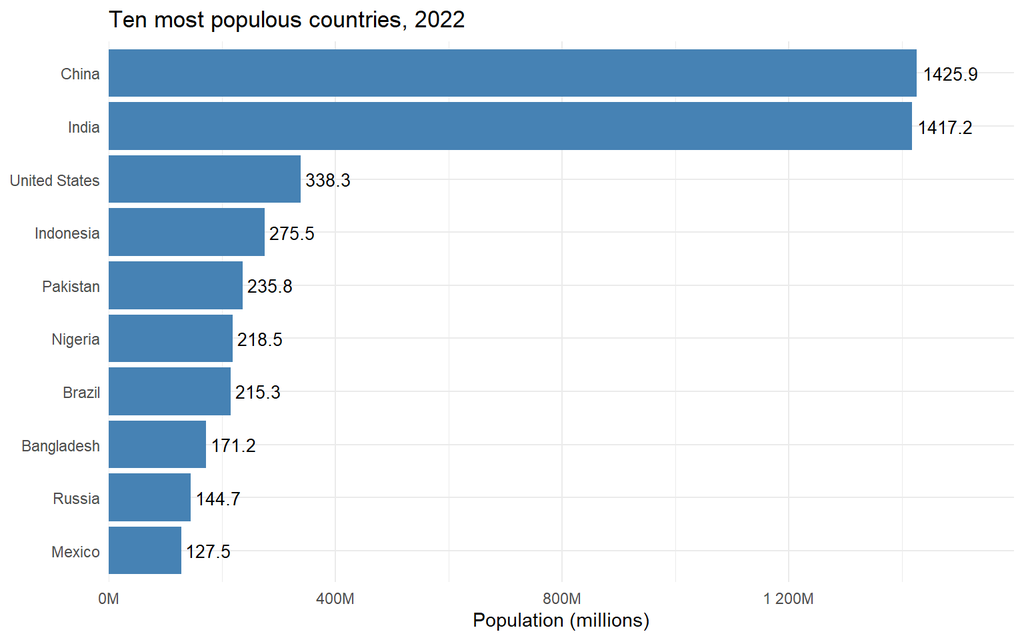

```r
ggplot(top10, aes(x = reorder(`Country/Territory`, `2022 Population`),
                  y = `2022 Population`)) +
  geom_col(fill = "steelblue") +
  geom_text(aes(label = round(`2022 Population` / 1e6, 1)), hjust = -0.1, size = 3.5) +
  coord_flip() +
  scale_y_continuous(labels = label_number(scale = 1e-6, suffix = "M"),
                     expand = expansion(mult = c(0, .12))) +
  labs(title = "Ten most populous countries, 2022",
       x = NULL, y = "Population (millions)") +
  theme_minimal()
```

## 2. Population trend 1990–2022

The dataset only contains census-year snapshots (1990, 2000, 2010, 2015, 2020, 2022), not every year, so the trend is drawn through those points.

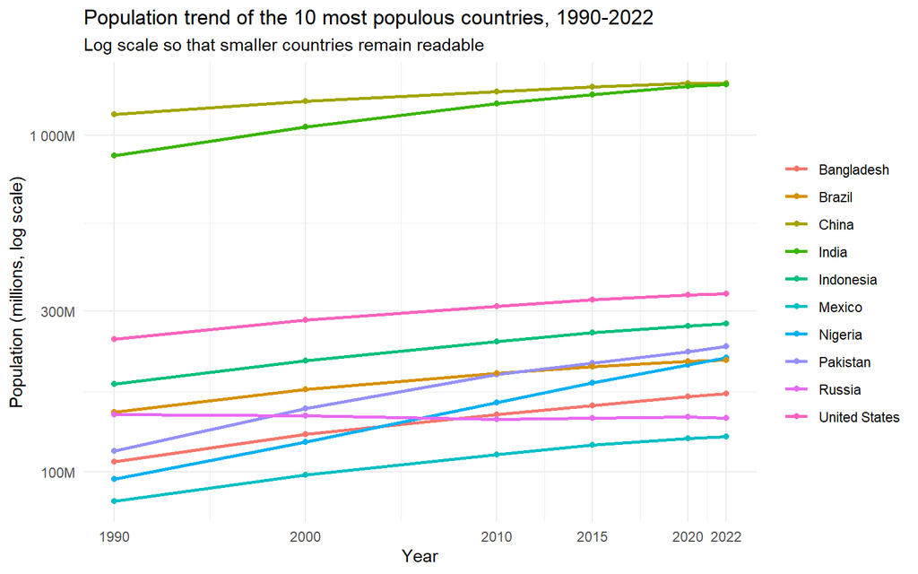

```r
trend <- top10 |>
  select(country = `Country/Territory`, `1990 Population`, `2000 Population`,
         `2010 Population`, `2015 Population`, `2020 Population`, `2022 Population`) |>
  pivot_longer(-country, names_to = "year", values_to = "population") |>
  mutate(year = as.numeric(substr(year, 1, 4)))

ggplot(trend, aes(year, population, colour = country)) +
  geom_line(linewidth = 1) + geom_point() +
  scale_y_log10(labels = label_number(scale = 1e-6, suffix = "M")) +
  scale_x_continuous(breaks = unique(trend$year)) +
  labs(title = "Population trend of the 10 most populous countries, 1990-2022",
       subtitle = "Log scale so that smaller countries remain readable",
       x = "Year", y = "Population (millions, log scale)", colour = NULL) +
  theme_minimal()
```

## 3. CO2 emission trend 1990–2019

The CO2 file uses World Bank country names, so a few names differ from the population file (for example *Russian Federation* vs *Russia*). We harmonise them first.

```r
name_map <- c("Bahamas, The" = "Bahamas", "Brunei Darussalam" = "Brunei",
  "Cabo Verde" = "Cape Verde", "Congo, Dem. Rep." = "DR Congo",
  "Congo, Rep." = "Republic of the Congo", "Cote d'Ivoire" = "Ivory Coast",
  "Egypt, Arab Rep." = "Egypt", "Gambia, The" = "Gambia",
  "Hong Kong SAR, China" = "Hong Kong", "Iran, Islamic Rep." = "Iran",
  "Korea, Dem. People's Rep." = "North Korea", "Korea, Rep." = "South Korea",
  "Kyrgyz Republic" = "Kyrgyzstan", "Lao PDR" = "Laos",
  "Macao SAR, China" = "Macau", "Micronesia, Fed. Sts." = "Micronesia",
  "Russian Federation" = "Russia", "Sint Maarten (Dutch part)" = "Sint Maarten",
  "Slovak Republic" = "Slovakia", "St. Kitts and Nevis" = "Saint Kitts and Nevis",
  "St. Lucia" = "Saint Lucia", "St. Martin (French part)" = "Saint Martin",
  "St. Vincent and the Grenadines" = "Saint Vincent and the Grenadines",
  "Syrian Arab Republic" = "Syria", "Turkiye" = "Turkey",
  "Venezuela, RB" = "Venezuela", "Virgin Islands (U.S.)" = "United States Virgin Islands",
  "West Bank and Gaza" = "Palestine", "Yemen, Rep." = "Yemen")

co2$Country <- ifelse(co2$Country.Name %in% names(name_map),
                      name_map[co2$Country.Name], co2$Country.Name)

# Names that still do not match (these are simply absent from one of the files)
setdiff(co2$Country, pop$`Country/Territory`)
```

```
## character(0)
```

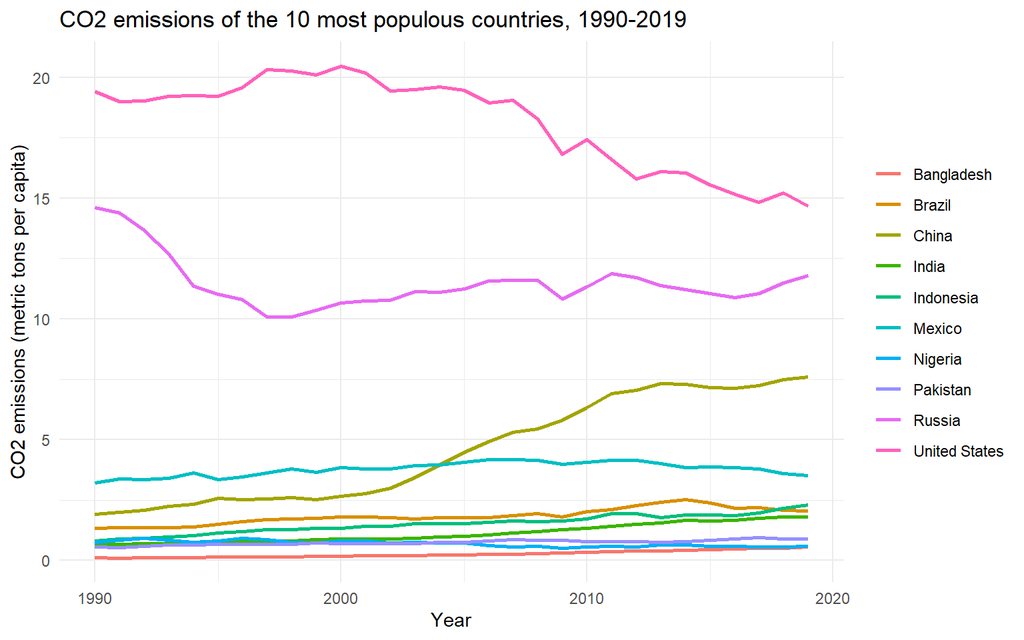

```r
co2_top <- co2 |>
  filter(Country %in% top10$`Country/Territory`) |>
  select(Country, starts_with("X")) |>
  pivot_longer(-Country, names_to = "year", values_to = "co2") |>
  mutate(year = as.numeric(sub("X", "", year)))

ggplot(co2_top, aes(year, co2, colour = Country)) +
  geom_line(linewidth = 1) +
  labs(title = "CO2 emissions of the 10 most populous countries, 1990-2019",
       x = "Year", y = "CO2 emissions (metric tons per capita)", colour = NULL) +
  theme_minimal()
```

# 4.5 Correlation analysis

## 1. Area, Density, Growth Rate and World Population Percentage

```r
vars <- pop |>
  select(Area = Area_km2, Density = Density_km2,
         Growth_Rate = `Growth Rate`, World_Pop_Pct = `World Population Percentage`)

cor_p <- round(cor(vars, method = "pearson"), 2)
cor_s <- round(cor(vars, method = "spearman"), 2)
cor_p   # Pearson (sensitive to outliers)
```

```
##                Area Density Growth_Rate World_Pop_Pct
## Area           1.00   -0.06       -0.01          0.45
## Density       -0.06    1.00       -0.07         -0.03
## Growth_Rate   -0.01   -0.07        1.00         -0.02
## World_Pop_Pct  0.45   -0.03       -0.02          1.00
```

```r
cor_s   # Spearman (rank based, robust to outliers)
```

```
##                Area Density Growth_Rate World_Pop_Pct
## Area           1.00   -0.58        0.36          0.84
## Density       -0.58    1.00       -0.22         -0.15
## Growth_Rate    0.36   -0.22        1.00          0.28
## World_Pop_Pct  0.84   -0.15        0.28          1.00
```

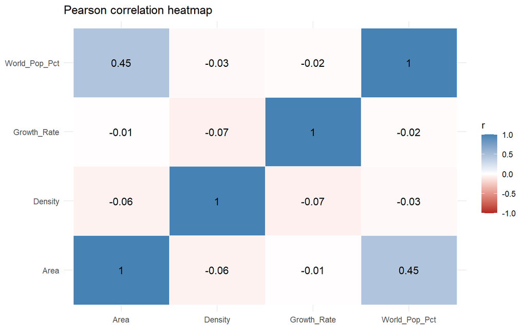

```r
heat <- function(m, ttl) {
  ggplot(melt(m), aes(Var1, Var2, fill = value)) +
    geom_tile(colour = "white") +
    geom_text(aes(label = value), size = 4) +
    scale_fill_gradient2(low = "firebrick", mid = "white", high = "steelblue",
                         midpoint = 0, limits = c(-1, 1)) +
    labs(title = ttl, x = NULL, y = NULL, fill = "r") +
    theme_minimal()
}
heat(cor_p, "Pearson correlation heatmap")
```

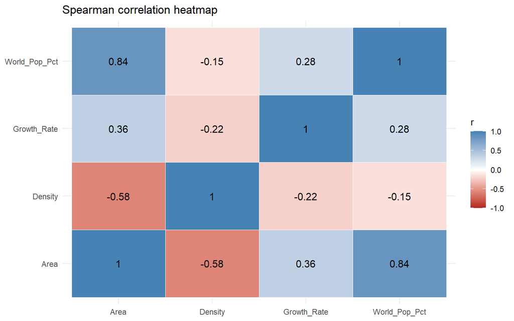

```r
heat(cor_s, "Spearman correlation heatmap")
```

## 2. Population (2022) versus CO2 emissions (2019)

```r
merged <- pop |>
  select(Country = `Country/Territory`, Continent, CCA3,
         pop2022 = `2022 Population`) |>
  inner_join(co2 |> select(Country, Region, co2_2019 = X2019), by = "Country") |>
  filter(!is.na(co2_2019))

dim(merged)
```

```
## [1] 191   6
```

```r
head(merged)
```

```
##               Country     Continent CCA3  pop2022                     Region
## 1         Afghanistan          Asia  AFG 41128771                 South Asia
## 2             Albania        Europe  ALB  2842321      Europe & Central Asia
## 3             Algeria        Africa  DZA 44903225 Middle East & North Africa
## 4             Andorra        Europe  AND    79824      Europe & Central Asia
## 5              Angola        Africa  AGO 35588987         Sub-Saharan Africa
## 6 Antigua and Barbuda North America  ATG    93763  Latin America & Caribbean
##    co2_2019
## 1 0.1598244
## 2 1.6922483
## 3 3.9776505
## 4 6.4812174
## 5 0.7921371
## 6 5.3544765
```

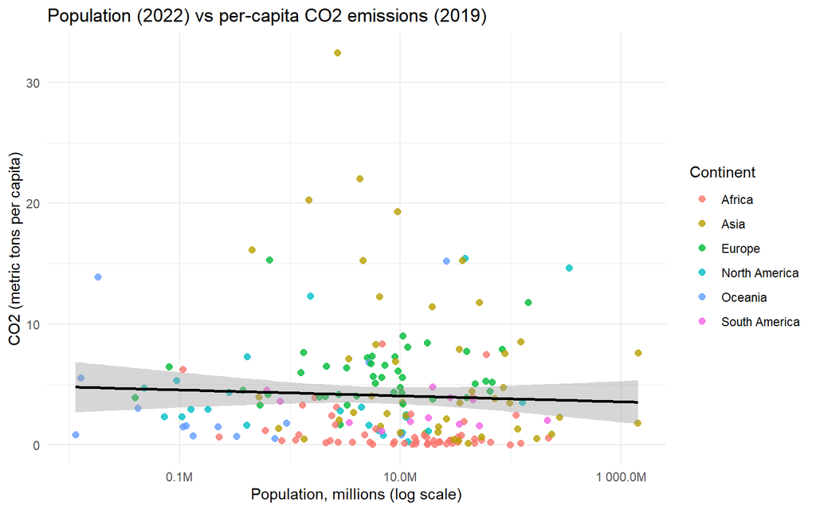

```r
ggplot(merged, aes(pop2022, co2_2019)) +
  geom_point(aes(colour = Continent), alpha = .8, size = 2) +
  geom_smooth(method = "lm", colour = "black", se = TRUE) +
  scale_x_log10(labels = label_number(scale = 1e-6, suffix = "M")) +
  labs(title = "Population (2022) vs per-capita CO2 emissions (2019)",
       x = "Population, millions (log scale)",
       y = "CO2 (metric tons per capita)") +
  theme_minimal()
```

```r
cor.test(merged$pop2022, merged$co2_2019, method = "pearson")
```

```
##
##  Pearson's product-moment correlation
##
## data:  merged$pop2022 and merged$co2_2019
## t = 0.19882, df = 189, p-value = 0.8426
## alternative hypothesis: true correlation is not equal to 0
## 95 percent confidence interval:
##  -0.1277814  0.1561191
## sample estimates:
##        cor
## 0.01446026
```

```r
cor.test(merged$pop2022, merged$co2_2019, method = "spearman", exact = FALSE)
```

```
##
##  Spearman's rank correlation rho
##
## data:  merged$pop2022 and merged$co2_2019
## S = 1289342, p-value = 0.1288
## alternative hypothesis: true rho is not equal to 0
## sample estimates:
##        rho
## -0.1102766
```

```r
fit <- lm(co2_2019 ~ log10(pop2022), data = merged)
summary(fit)
```

```
##
## Call:
## lm(formula = co2_2019 ~ log10(pop2022), data = merged)
##
## Residuals:
##    Min     1Q Median     3Q    Max
## -4.083 -3.216 -1.492  1.462 28.263
##
## Coefficients:
##                Estimate Std. Error t value Pr(>|t|)
## (Intercept)      5.7780     2.4914   2.319   0.0215 *
## log10(pop2022)  -0.2437     0.3616  -0.674   0.5013
## ---
## Signif. codes:  0 '***' 0.001 '**' 0.01 '*' 0.05 '.' 0.1 ' ' 1
##
## Residual standard error: 4.721 on 189 degrees of freedom
## Multiple R-squared:  0.002396,   Adjusted R-squared:  -0.002882
## F-statistic: 0.454 on 1 and 189 DF,  p-value: 0.5013
```

**Interpretation.** Because the CO2 variable is *per capita*, a large population does not automatically mean higher per-capita emissions. The correlation is expected to be weak: per-capita emissions are driven mainly by income, energy mix and industrial structure, not by country size. Spearman and the log-scale regression are preferred over raw Pearson because population is extremely right-skewed.

# 4.6 CO2 emissions by continent (2019)

The 2019 values are summed by continent (continent comes from the population dataset).

```r
cont <- merged |>
  group_by(Continent) |>
  summarise(total_co2 = sum(co2_2019), n_countries = n()) |>
  arrange(desc(total_co2))
cont
```

```
## # A tibble: 6 × 3
##   Continent     total_co2 n_countries
##   <chr>             <dbl>       <int>
## 1 Asia              291.           46
## 2 Europe            247.           42
## 3 North America      96.9          23
## 4 Africa             63.7          54
## 5 Oceania            54.8          14
## 6 South America      33.4          12
```

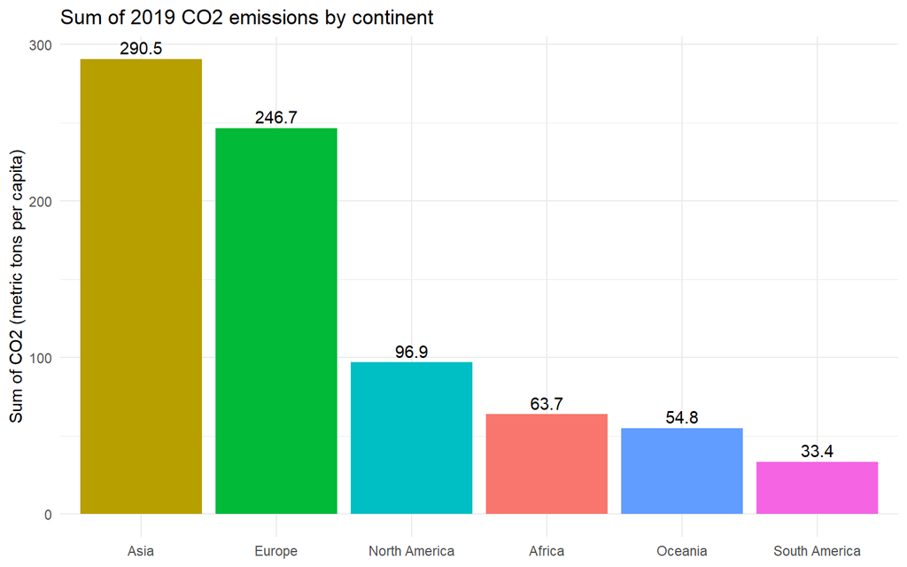

```r
ggplot(cont, aes(reorder(Continent, -total_co2), total_co2, fill = Continent)) +
  geom_col(show.legend = FALSE) +
  geom_text(aes(label = round(total_co2, 1)), vjust = -0.4) +
  labs(title = "Sum of 2019 CO2 emissions by continent",
       x = NULL, y = "Sum of CO2 (metric tons per capita)") +
  theme_minimal()
```

```r
cat("1. **Highest emitting continent:** ", cont$Continent[1],
    " (", round(cont$total_co2[1], 2), ")\n\n", sep = "")
```

1. **Highest emitting continent:** Asia (290.55)

```r
cat("2. **Third continent:** ", cont$Continent[3],
    " — total ", round(cont$total_co2[3], 2), " metric tons per capita\n\n", sep = "")
```

2. **Third continent:** North America — total 96.9 metric tons per capita

```r
cat("3. **Last continent:** ", cont$Continent[nrow(cont)],
    " — total ", round(cont$total_co2[nrow(cont)], 2), " metric tons per capita\n", sep = "")
```

3. **Last continent:** South America — total 33.36 metric tons per capita

```r
merged |>
  group_by(Continent) |>
  summarise(mean_co2 = round(mean(co2_2019), 2), n_countries = n()) |>
  arrange(desc(mean_co2))
```

```
## # A tibble: 6 × 3
##   Continent     mean_co2 n_countries
##   <chr>            <dbl>       <int>
## 1 Asia              6.32          46
## 2 Europe            5.87          42
## 3 North America     4.21          23
## 4 Oceania           3.91          14
## 5 South America     2.78          12
## 6 Africa            1.18          54
```